# Data Manipulation and Analysis with R

September 8, 2019

## R Basics

## What is R?

From `https://www.r-project.org/about.html`…

R is a language and environment for statistical computing and graphics…R provides a wide variety of statistical (…) and graphical techniques, and is highly extensible…R provides an **Open Source** route…R is available as **Free** Software under the terms of the Free Software Foundation’s GNU General Public License in source code form…

## What is R?

From `https://www.r-project.org/about.html`…

R is a language and environment for statistical computing and graphics…R provides a wide variety of statistical (…) and graphical techniques, and is highly extensible…R provides an **Open Source** route…R is available as **Free** Software under the terms of the Free Software Foundation’s GNU General Public License in source code form…

### Open Source and free

- No money? No problem.
- You can also contribute to the community.

## What is R?

From `https://www.r-project.org/about.html`…

R is a **language** and **environment** for statistical computing and graphics…R provides a wide variety of statistical (…) and graphical techniques, and is highly extensible…

### A language

- Allows you to **instruct** computers to perform statistical tasks.
- Needs to learn the language.

### An environment

- You need the `R` environment so your computer can understand the `R` instructions.
- `R` installation comes with a basic source code editor.

## RStudio

### RStudio

- A popular IDE dedicated to `R`.
- Provides an integrated GUI for source code editing, plotting, and debugging among other features.
- This document was created in `RStudio`.

### Installation

- Download `R` from https://www.r-project.org/.
- Download `RStudio` from https://www.rstudio.com/products/rstudio/download/  
  (Use *RStudio Desktop* free version).
- Install `R` before installing `RStudio`.

## Data types

### Basic types

- Numeric (real numbers)

```r
1/7
```

- Integer

```r
30
```

- Complex

```r
3+2i
```

- Logical

```r
30==30
# TRUE <- this is a comment
```

- Character (not a number)

```r
as.character(3.14)
# "3.14" not a number
```

## Data types

### Not allowed

```r
as.character(3.14) + 1
```

`Error in as.character(3.14) + 1 : non-numeric argument to binary operator`

### Allowed

```r
TRUE + 3 # TRUE evaluates to 1; FALSE to 0
```

```
## [1] 4
```

## Data types

### Vector

- A sequence of elements of the **same** basic data type.

```r
c(1,FALSE,0.5)
```

```
## [1] 1.0 0.0 0.5
```

```r
c(1,FALSE,'a')[2]
```

```
## [1] "FALSE"
```

### Matrix

- Two dimensional collection of elements of the **same** basic data type.

```r
matrix(
  c(1:9),
  nrow=3, ncol=3,
  byrow=TRUE
)
```

```
##      [,1] [,2] [,3]
## [1,]    1    2    3
## [2,]    4    5    6
## [3,]    7    8    9
```

## Data types

### List

- A generic vector containing other objects.

```r
list.w.vector <- list(
  1.5,TRUE,'a',a=c(1:5))
list.w.vector[[3]]
```

```
## [1] "a"
```

```r
list.w.vector$a[1]
```

```
## [1] 1
```

## Data types

### Data frame

- A list of vectors of equal length used to store data tables.

```r
df <- data.frame(
  ALPHABET=letters[1:4],
  INTEGER=c(1:4),
  SQRT=sqrt(c(1:4)),
  GUESSME=c(TRUE,1.2,'0',NA)
)
```

## Data types

### Data frame

- A list of vectors of equal length used to store data tables.

```r
df <- data.frame(
  ALPHABET=letters[1:4],
  INTEGER=c(1:4),
  SQRT=sqrt(c(1:4)),
  GUESSME=c(TRUE,1.2,'0',NA)
)
```

| ALPHABET | INTEGER | SQRT | GUESSME |
| --- | --- | --- | --- |
| a | 1 | 1.000 | TRUE |
| b | 2 | 1.414 | 1.2 |
| c | 3 | 1.732 | 0 |
| d | 4 | 2.000 | NA |

## Getting help

- Type `?` followed by a function name.

```r
?help
```

- Or use the search box in `RStudio` under `Help` tab.
- Or ask the Internet.

Get used to reading the documentation.

## Other topics

- Scalar vs. vectorised functions, i.e., functions that work on a single value vs. al values in a vector.
- Family of `apply` functions.
- User-defined functions.

```r
sum(1:4)
```

```
## [1] 10
```

```r
sapply(df$INTEGER, function(x) { if(x>2) x else -1 })
```

```
## [1] -1 -1  3  4
```

## Data Inspection and Manipulation

## Import data

### `read.csv`

- Creates a data frame from a csv file.

```r
df <- read.csv('./path/to/file.csv', sep=",", header=TRUE, ...)
```

### `readLines`

- Reads text lines from a connection.
- Doesn't have to be a csv.
- Useful when you don't want to read only a part of a large text file to prevent memory outage.

```r
readLines('./path/to/file.txt', n=-1L) # read all lines
readLines('./path/to/file.txt', n=5) # read first 5 lines
```

## Import data

### Example

- Data retreived from [BuzzFeed Github Repository (https://github.com/BuzzFeedNews/2015-12-mass-shooting-intervals)](https://github.com/BuzzFeedNews/2015-12-mass-shooting-intervals).

```r
df <- read.csv('data/shooting-usa.csv')
```

| Date | Dead | Injured | Location |
| --- | --- | --- | --- |
| 1/1/2013 | 4 | 0 | Sacramento, CA |
| 1/1/2013 | 1 | 3 | Hawthorne, CA |
| 1/1/2013 | 0 | 4 | McKeesport, PA |
| 1/1/2013 | 1 | 4 | Lorain, OH |
| 1/5/2013 | 4 | 0 | Aurora, CO |
| 1/7/2013 | 5 | 0 | Tulsa, OK |

## Basic inspection

### `head` and `tail`

- Displays first or last parts of data.

```r
head(df)
```

```
##       Date Dead Injured       Location
## 1 1/1/2013    4       0 Sacramento, CA
## 2 1/1/2013    1       3  Hawthorne, CA
## 3 1/1/2013    0       4 McKeesport, PA
## 4 1/1/2013    1       4     Lorain, OH
## 5 1/5/2013    4       0     Aurora, CO
## 6 1/7/2013    5       0      Tulsa, OK
```

## Basic inspection

### `dim`

- Returns the number of rows x the number of columns.
- Use `length` for vectors and lists.

```r
dim(df)
```

```
## [1] 1050    4
```

## Basic inspection

### `str`

- Displays the internal structure of the object.

```r
str(df)
```

```
## 'data.frame':    1050 obs. of  4 variables:
##  $ Date    : Factor w/ 613 levels "1/1/2013","1/1/2014",..: 1 1 1 1 36 39 39 39 4 7 ...
##  $ Dead    : int  4 1 0 1 4 5 2 3 3 1 ...
##  $ Injured : int  0 3 4 4 0 0 2 1 2 4 ...
##  $ Location: Factor w/ 557 levels " Fort Bend County, TX",..: 429 209 294 272 27 507 192 134 328 508 ...
```

## Basic inspection

### `summary`

- Displays basic summaries for each column.

```r
summary(df)
```

```
##          Date           Dead           Injured                  Location
##  10/27/2013:   6   Min.   : 0.000   Min.   : 0.000   Chicago, IL    : 42
##  6/13/2015 :   6   1st Qu.: 0.000   1st Qu.: 3.000   New Orleans, LA: 20
##  8/18/2013 :   6   Median : 1.000   Median : 4.000   St. Louis, MO  : 17
##  9/15/2013 :   6   Mean   : 1.269   Mean   : 3.616   Baltimore, MD  : 16
##  11/22/2015:   5   3rd Qu.: 2.000   3rd Qu.: 4.000   Brooklyn, NY   : 15
##  12/22/2014:   5   Max.   :13.000   Max.   :19.000   Houston, TX    : 14
##  (Other)   :1016                                     (Other)        :926
```

## Basic manipulation

### Data class conversion

- `Date` is coded as a `Factor`.
- `Factor` variables are categorical.
- We want `Date` to represent…dates.

```r
as.Date(vector, 'Format')
```

## Basic manipulation

### Data class conversion

```r
df$Location <- as.character(df$Location)
df$Date <- as.Date(df$Date, '%m/%d/%Y')
str(df)
```

```
## 'data.frame':    1050 obs. of  4 variables:
##  $ Date    : Date, format: "2013-01-01" "2013-01-01" ...
##  $ Dead    : int  4 1 0 1 4 5 2 3 3 1 ...
##  $ Injured : int  0 3 4 4 0 0 2 1 2 4 ...
##  $ Location: chr  "Sacramento, CA" "Hawthorne, CA" "McKeesport, PA" "Lorain, OH" ...
```

## Basic manipulation

### Data class conversion

- Allows methods specific to `Date` class.

```r
df$Year <- as.numeric(format(df$Date,'%Y'))
df$Month <- months(df$Date)
df$Week.Day <- weekdays(df$Date)
df$Date.Ind <- julian(df$Date, as.Date('2013-01-01'))
head(df[c('Date', 'Year', 'Month', 'Week.Day', 'Date.Ind')])
```

```
##         Date Year   Month Week.Day Date.Ind
## 1 2013-01-01 2013 January  Tuesday        0
## 2 2013-01-01 2013 January  Tuesday        0
## 3 2013-01-01 2013 January  Tuesday        0
## 4 2013-01-01 2013 January  Tuesday        0
## 5 2013-01-05 2013 January Saturday        4
## 6 2013-01-07 2013 January   Monday        6
```

## Basic manipulation

### Data class conversion

- `Month` and `Week.Day` can be coded as `Factor`s.

```r
df$Month <- factor(
  df$Month,
  c('January', 'February', 'March', 'April', 'May', 'June',
    'July', 'August', 'September', 'October', 'November', 'December'))
df$Week.Day <- factor(
  df$Week.Day, c('Sunday', 'Monday', 'Tuesday',
                 'Wednesday', 'Thursday', 'Friday', 'Saturday'))
```

## Basic manipulation

### Text manipulation

- Part of text can be extracted by pattern.

```r
head(df$Location)
```

```
## [1] "Sacramento, CA" "Hawthorne, CA"  "McKeesport, PA" "Lorain, OH"
## [5] "Aurora, CO"     "Tulsa, OK"
```

## Basic manipulation

### Text manipulation

- Part of text can be extracted by pattern.

```r
df$State <- sub('.*, ?', '', df$Location)
unique(df$State)
```

```
##  [1] "CA"            "PA"            "OH"            "CO"
##  [5] "OK"            "NC"            "VA"            "LA"
##  [9] "AL"            "NM"            "MO"            "Washington DC"
## [13] "AZ"            "TN"            "IL"            "MN"
## [17] "DE"            "UT"            "FL"            "MI"
## [21] "GA"            "TX"            "IN"            "MS"
## [25] "NY"            "DC"            "IA"            "WA"
## [29] "Puerto Rico"   "SC"            "Kansas"        "KY"
## [33] "MA"            "Illinois"      "Louisiana"     "Ohio"
## [37] "KA"            "Tennessee"     "NJ"            "PR"
## [41] "NV"            "WI"            "RI"            "MD"
## [45] "ME"            "KS"            "CT"            "WV"
## [49] "Mo"            "NE"            "Ga"            "Il"
## [53] "OR"            "Ca"            "In"            "Mi"
## [57] "Tx"            "Fl"            "Az"            "Ok"
## [61] "Ma"            "AR"            "AK"            "SD"
## [65] "ID"            "MT"            "D.C."          "VT"
```

## Basic manipulation

### Text manipulation

- And more…

```r
df$State <- toupper(df$State)
df$State[grep('D.?C.?', df$State)] <- 'DC'
df$State[grep('ILLINOIS', df$State)] <- 'IL'
df$State[grep('KANSAS', df$State)] <- 'KS'
df$State[grep('LOUISIANA', df$State)] <- 'LA'
df$State[grep('PUERTO', df$State)] <- 'PR'
df$State[grep('TENNESSEE', df$State)] <- 'TN'
sort(unique(df$State))
```

```
##  [1] "AK"   "AL"   "AR"   "AZ"   "CA"   "CO"   "CT"   "DC"   "DE"   "FL"
## [11] "GA"   "IA"   "ID"   "IL"   "IN"   "KA"   "KS"   "KY"   "LA"   "MA"
## [21] "MD"   "ME"   "MI"   "MN"   "MO"   "MS"   "MT"   "NC"   "NE"   "NJ"
## [31] "NM"   "NV"   "NY"   "OH"   "OHIO" "OK"   "OR"   "PA"   "PR"   "RI"
## [41] "SC"   "SD"   "TN"   "TX"   "UT"   "VA"   "VT"   "WA"   "WI"   "WV"
```

## Basic manipulation

### `rbind` and `cbind`

- Combine R Objects (e.g., data frames) by rows or columns.

```r
# Example
df.2013 <- read.csv('path/to/file2013.csv')
df.2014 <- read.csv('path/to/file2014.csv')
df.2015 <- read.csv('path/to/file2015.csv')
# combine
df.all <- rbind(
  df.2013, df.2014, df.2015
)
```

## Basic Plotting

## Histogram

```r
hist(value.vector, ...)
```

## Scatter plot

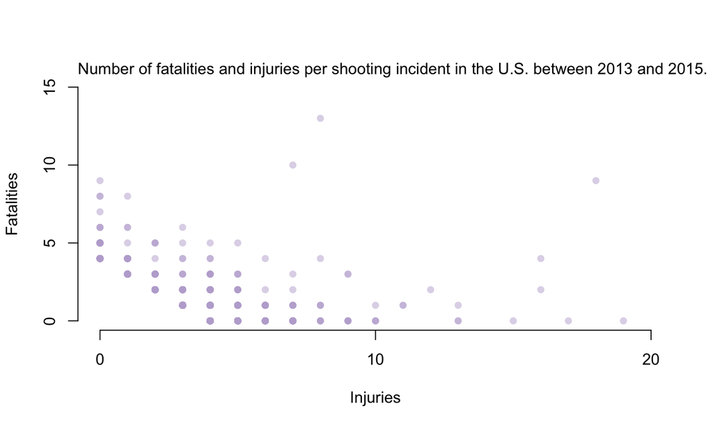

```r
plot(x.vector, y.vector, col=color, ...)
points(x.vector, y.vector, col=color, ...)
```

## Line chart

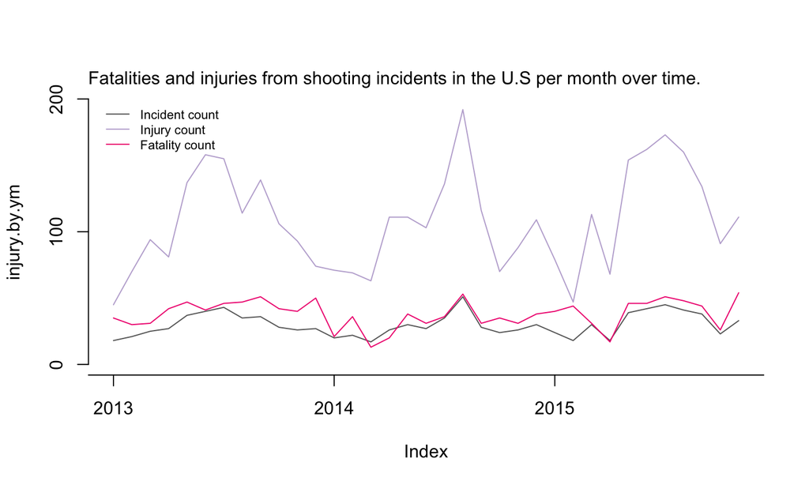

```r
plot(x.vector, y.vector, type='l', col=color, ...)
lines(x.vector, y.vector, col=color, ...)
```

## Bar plot

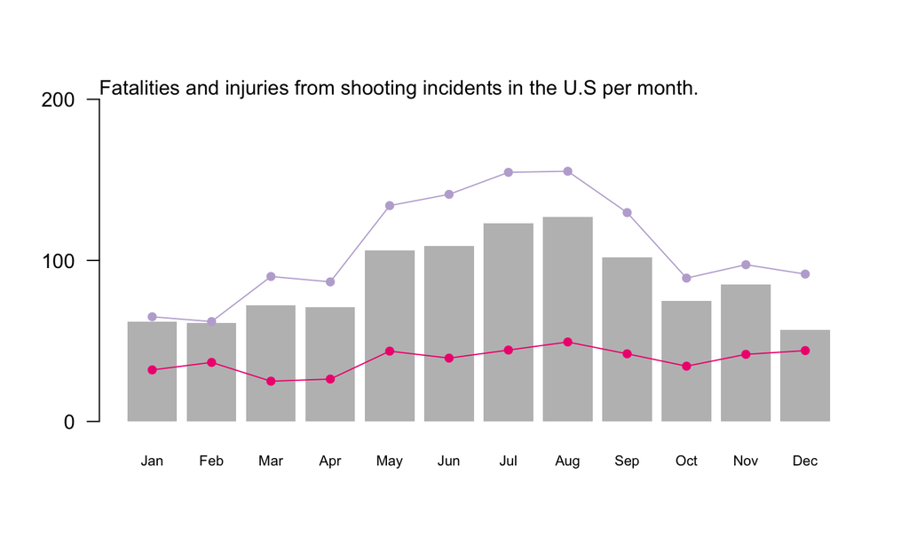

```r
barplot(height.vector, ...)
```

## Model Fitting

## Linear regression

```r
fitted <- lm(formula=y~x1+x2, data=df, ...)
summary(fitted)
```

## Example

### Generalized additive model

\[ \rm{Casualties}_i \sim \mathcal{N}(\mu_i, \sigma^2) \\ \mu_i = \beta_0+\rm{Month}_i\beta + f(\rm{Week}_i,\nu) \]

## Example

```r
library(mgcv)
df$Casualty <- df$Injured + df$Dead
df$Week.Ind <- floor(
  julian(df$Date, as.Date('2013-01-01'))/7
)
df.week <- aggregate(df$Casualty, list(Week=df$Week.Ind), sum)
names(df.week) <- c('Week', 'Count')
df.week$Date <- as.Date(as.POSIXct(
  df.week$Week*7*24*60*60, origin = "2013-01-01", tz="UTC"))
df.week$Month <- factor(
  months(df.week$Date),
  c('January', 'February', 'March', 'April', 'May', 'June',
    'July', 'August', 'September', 'October', 'November', 'December'))
fitted <- gam(Count ~ s(Week) + Month, data=df.week)
```

## Example

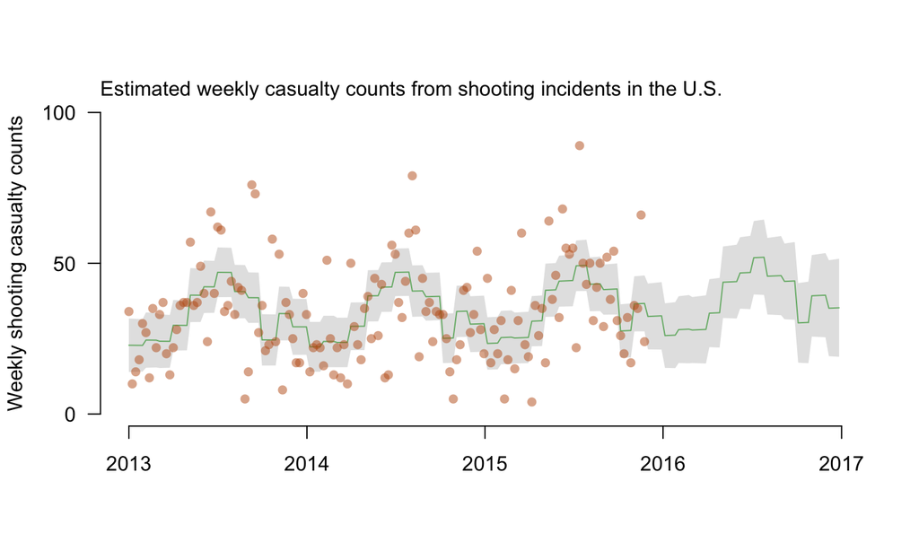

## Example

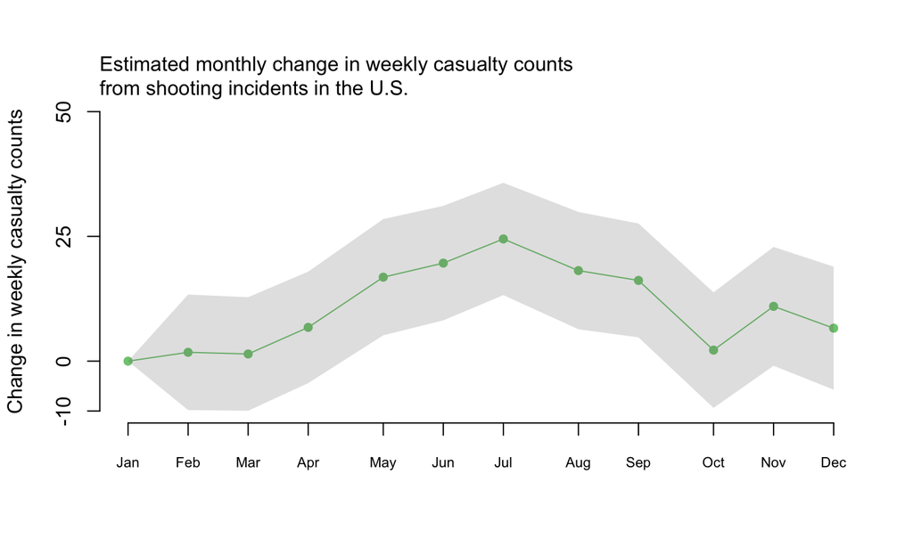

## Example

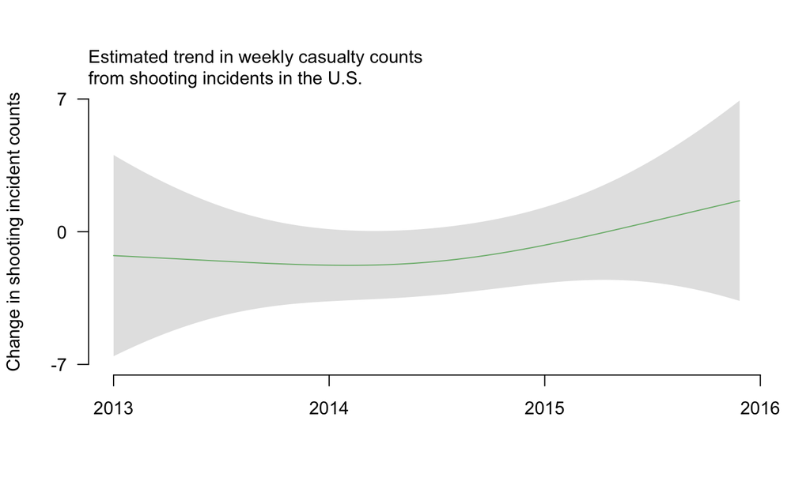

## Resources

## Resources

- [Codes for the workshop](https://github.com/mjmoon/r_workshop)
- [Search engien for `R` related stuff](https://rseek.org/)
- [`R` homepage](https://www.r-project.org/)
- http://www.r-tutor.com/r-introduction
- [Tutorial on R apply family](https://www.datacamp.com/community/tutorials/r-tutorial-apply-family)